# ess-330-lab06

Author

Caleb Cripe

# Project Setup

```r
options(repos = c(CRAN = "https://cloud.r-project.org/"))
library(tidyverse)
library(tidymodels)
install.packages("powerjoin")
library(powerjoin)
install.packages("glue")
library(glue)
install.packages("vip")
library(vip)
install.packages("baguette")
library(baguette)

root  <- 'https://gdex.ucar.edu/dataset/camels/file'

download.file('https://gdex.ucar.edu/dataset/camels/file/camels_attributes_v2.0.pdf',
              'data/camels_attributes_v2.0.pdf')

types <- c("clim", "geol", "soil", "topo", "vege", "hydro")

remote_files  <- glue('{root}/camels_{types}.txt')
local_files   <- glue('data/camels_{types}.txt')

walk2(remote_files, local_files, download.file, quiet = TRUE)

camels <- map(local_files, read_delim, show_col_types = FALSE)

camels <- power_full_join(camels ,by = 'gauge_id')
```

# Question 1

The zero_q_freq variable represents the frequency of days with Q = 0 mm/day in units of %, which was sourced from UGSG data. I found this by going into my data folder, opening the camels attributed pdf file, and scrolling down to find the variable.

# Question 2

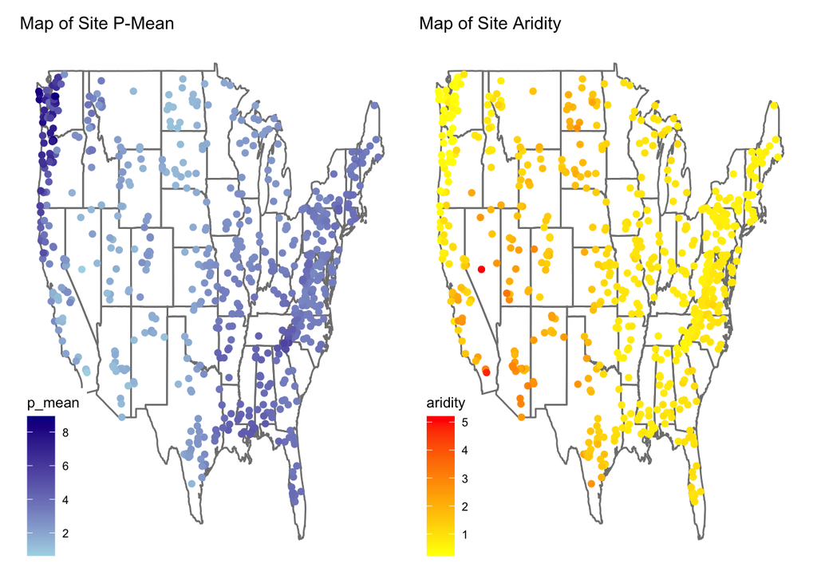

```r
install.packages("ggthemes")
install.packages("ggplot2")
install.packages("patchwork")
library(ggthemes)
library(ggplot2)
library(patchwork)

map_pmean <- ggplot(data = camels, aes(x = gauge_lon, y = gauge_lat)) +
  borders("state", colour = "gray50") +
  geom_point(aes(color = p_mean)) +
  scale_color_gradient(low = "lightblue", high = "darkblue") +
  ggthemes::theme_map() +
  ggtitle("Map of Site P-Mean") +
  labs(color = "p_mean")

map_aridity <- ggplot(data = camels, aes(x = gauge_lon, y = gauge_lat)) +
  borders("state", colour = "gray50") +
  geom_point(aes(color = aridity)) +
  scale_color_gradient(low = "yellow", high = "red") +
  ggthemes::theme_map() +
  ggtitle("Map of Site Aridity") +
  labs(color = "aridity")

map_pmean + map_aridity + plot_layout(widths = c(1, 1))
```

# Question 3

```r
set.seed(64)

camels <- camels |>
  mutate(logQmean = log(q_mean))

camels_split <- initial_split(camels, prop = 0.8)
camels_train <- training(camels_split)
camels_test  <- testing(camels_split)

camels_cv <- vfold_cv(camels_train, v = 10)
rec <-  recipe(logQmean ~ aridity + p_mean, data = camels_train) %>%
  step_log(all_predictors()) %>%
  step_interact(terms = ~ aridity:p_mean) |>
  step_naomit(all_predictors(), all_outcomes())

baked_data <- prep(rec, camels_train) |>
  bake(new_data = NULL)

lm_base <- lm(logQmean ~ aridity * p_mean, data = baked_data)
summary(lm_base)
```

```
Call:
lm(formula = logQmean ~ aridity * p_mean, data = baked_data)

Residuals:
     Min       1Q   Median       3Q      Max
-2.98476 -0.22376 -0.00187  0.22384  2.66367

Coefficients:
               Estimate Std. Error t value Pr(>|t|)
(Intercept)    -1.84340    0.17458 -10.559  < 2e-16 ***
aridity        -0.73304    0.17247  -4.250 2.52e-05 ***
p_mean          1.55140    0.16462   9.424  < 2e-16 ***
aridity:p_mean  0.04786    0.07875   0.608    0.544
---
Signif. codes:  0 '***' 0.001 '**' 0.01 '*' 0.05 '.' 0.1 ' ' 1

Residual standard error: 0.6042 on 531 degrees of freedom
Multiple R-squared:  0.7386,    Adjusted R-squared:  0.7371
F-statistic: 500.1 on 3 and 531 DF,  p-value: < 2.2e-16
```

```r
summary(lm(logQmean ~ aridity + p_mean + aridity_x_p_mean, data = baked_data))
```

```
Call:
lm(formula = logQmean ~ aridity + p_mean + aridity_x_p_mean,
    data = baked_data)

Residuals:
     Min       1Q   Median       3Q      Max
-2.98476 -0.22376 -0.00187  0.22384  2.66367

Coefficients:
                 Estimate Std. Error t value Pr(>|t|)
(Intercept)      -1.84340    0.17458 -10.559  < 2e-16 ***
aridity          -0.73304    0.17247  -4.250 2.52e-05 ***
p_mean            1.55140    0.16462   9.424  < 2e-16 ***
aridity_x_p_mean  0.04786    0.07875   0.608    0.544
---
Signif. codes:  0 '***' 0.001 '**' 0.01 '*' 0.05 '.' 0.1 ' ' 1

Residual standard error: 0.6042 on 531 degrees of freedom
Multiple R-squared:  0.7386,    Adjusted R-squared:  0.7371
F-statistic: 500.1 on 3 and 531 DF,  p-value: < 2.2e-16
```

```r
test_data <-  bake(prep(rec), new_data = camels_test)
test_data$lm_pred <- predict(lm_base, newdata = test_data)

install.packages("yardstick")
library(yardstick)
metrics(test_data, truth = logQmean, estimate = lm_pred)
```

```
# A tibble: 3 × 3
  .metric .estimator .estimate
  <chr>   <chr>          <dbl>
1 rmse    standard       0.428
2 rsq     standard       0.864
3 mae     standard       0.315
```

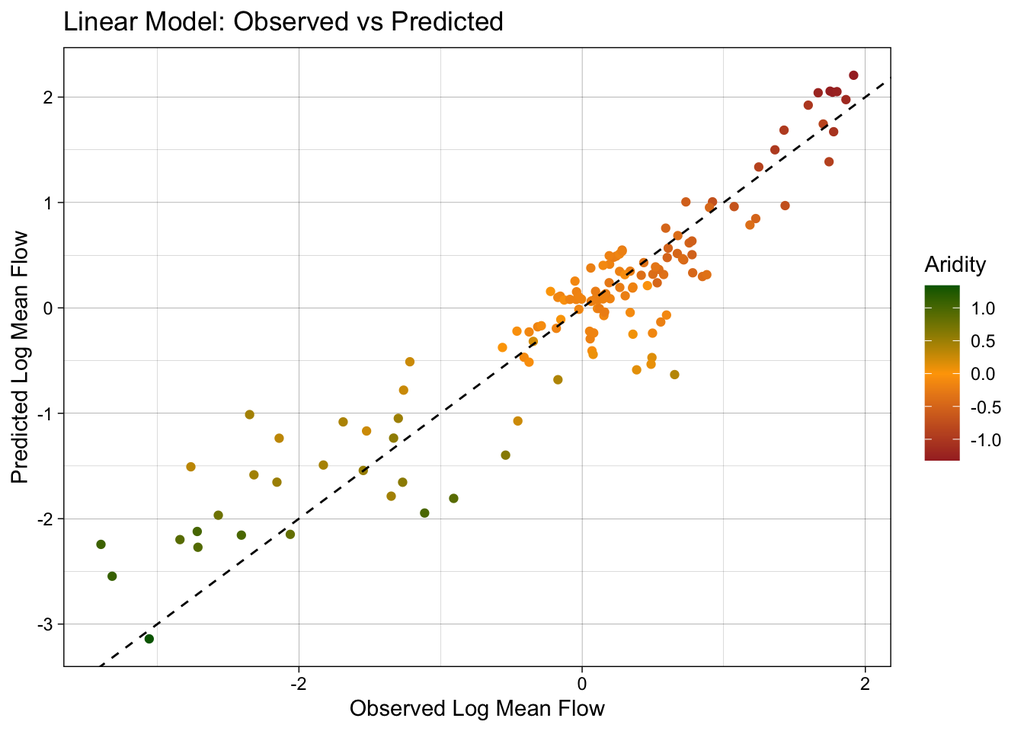

```r
ggplot(test_data, aes(x = logQmean, y = lm_pred, colour = aridity)) +
  scale_color_gradient2(low = "brown", mid = "orange", high = "darkgreen") +
  geom_point() +
  geom_abline(linetype = 2) +
  theme_linedraw() +
  labs(title = "Linear Model: Observed vs Predicted",
       x = "Observed Log Mean Flow",
       y = "Predicted Log Mean Flow",
       color = "Aridity")
```

```r
install.packages("parsnip")
library(parsnip)
library(workflows)
lm_model <- linear_reg() %>%
  set_engine("lm") %>%
  set_mode("regression")

lm_wf <- workflow() %>%
  add_recipe(rec) %>%
  add_model(lm_model) %>%
  fit(data = camels_train)

summary(extract_fit_engine(lm_wf))$coefficients
```

```
                    Estimate Std. Error     t value     Pr(>|t|)
(Intercept)      -1.84339837 0.17458191 -10.5589314 8.701460e-24
aridity          -0.73303858 0.17246844  -4.2502766 2.522239e-05
p_mean            1.55140187 0.16461798   9.4242554 1.327539e-19
aridity_x_p_mean  0.04785912 0.07875232   0.6077169 5.436351e-01
```

```r
summary(lm_base)$coefficients
```

```
                  Estimate Std. Error     t value     Pr(>|t|)
(Intercept)    -1.84339837 0.17458191 -10.5589314 8.701460e-24
aridity        -0.73303858 0.17246844  -4.2502766 2.522239e-05
p_mean          1.55140187 0.16461798   9.4242554 1.327539e-19
aridity:p_mean  0.04785912 0.07875232   0.6077169 5.436351e-01
```

```r
lm_data <- augment(lm_wf, new_data = camels_test)
dim(lm_data)
```

```
[1] 135  61
```

```r
metrics(lm_data, truth = logQmean, estimate = .pred)
```

```
# A tibble: 3 × 3
  .metric .estimator .estimate
  <chr>   <chr>          <dbl>
1 rmse    standard       0.428
2 rsq     standard       0.864
3 mae     standard       0.315
```

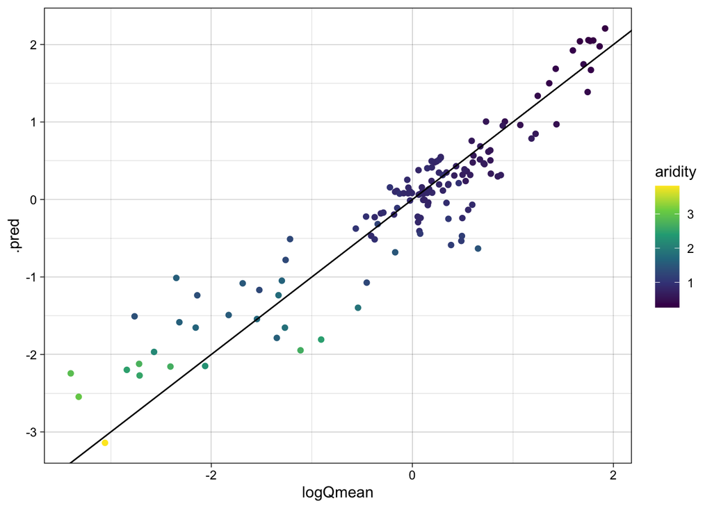

```r
ggplot(lm_data, aes(x = logQmean, y = .pred, colour = aridity)) +
  scale_color_viridis_c() +
  geom_point() +
  geom_abline() +
  theme_linedraw()
```

```r
library(baguette)
rf_model <- rand_forest() %>%
  set_engine("ranger", importance = "impurity") %>%
  set_mode("regression")

install.packages("ranger")
library(ranger)

rf_wf <- workflow() %>%
  add_recipe(rec) %>%
  add_model(rf_model) %>%
  fit(data = camels_train)

rf_data <- augment(rf_wf, new_data = camels_test)
dim(rf_data)
```

```
[1] 135  60
```

```r
metrics(rf_data, truth = logQmean, estimate = .pred)
```

```
# A tibble: 3 × 3
  .metric .estimator .estimate
  <chr>   <chr>          <dbl>
1 rmse    standard       0.414
2 rsq     standard       0.872
3 mae     standard       0.271
```

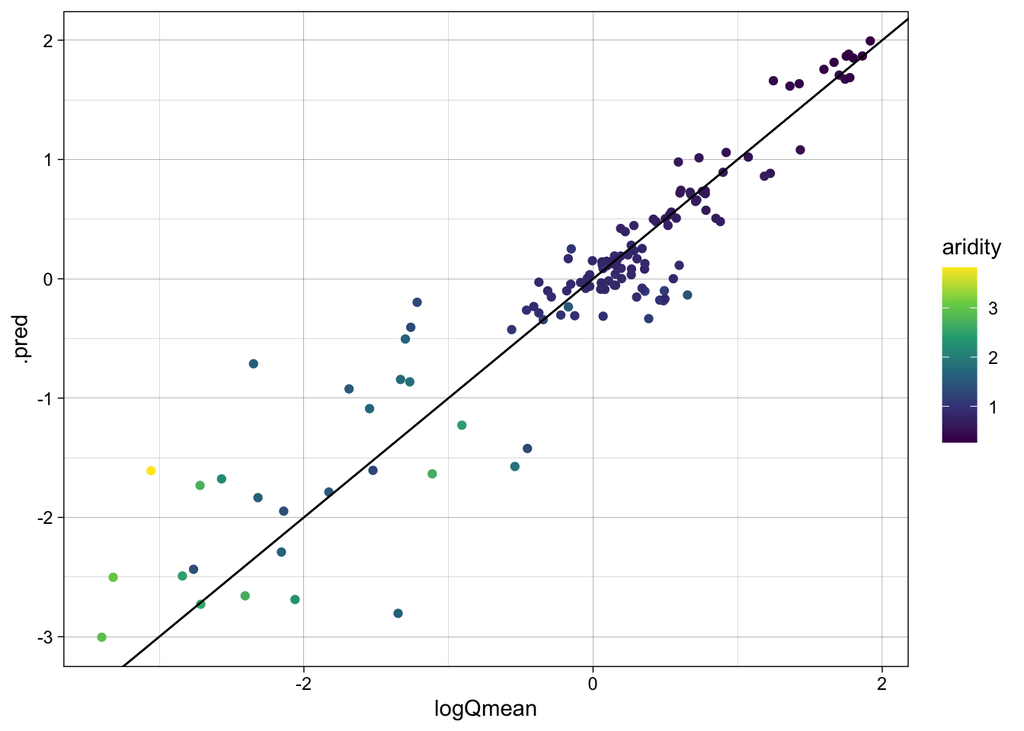

```r
ggplot(rf_data, aes(x = logQmean, y = .pred, colour = aridity)) +
  scale_color_viridis_c() +
  geom_point() +
  geom_abline() +
  theme_linedraw()
```

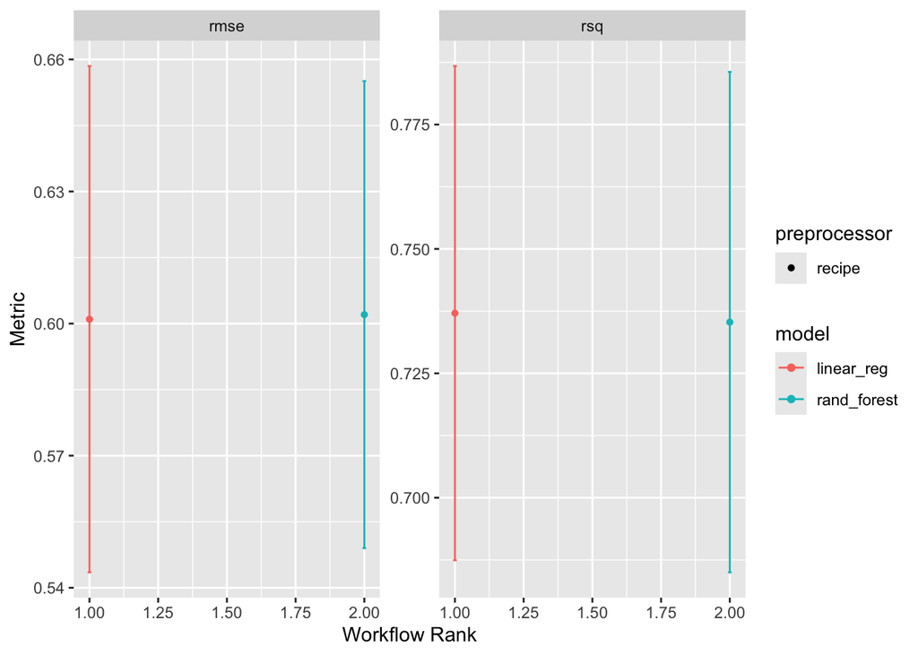

```r
wf <- workflow_set(list(rec), list(lm_model, rf_model)) %>%
  workflow_map('fit_resamples', resamples = camels_cv)

autoplot(wf)
```

```r
rank_results(wf, rank_metric = "rsq", select_best = TRUE)
```

```
# A tibble: 4 × 9
  wflow_id          .config .metric  mean std_err     n preprocessor model  rank
  <chr>             <chr>   <chr>   <dbl>   <dbl> <int> <chr>        <chr> <int>
1 recipe_linear_reg Prepro… rmse    0.601  0.0350    10 recipe       line…     1
2 recipe_linear_reg Prepro… rsq     0.737  0.0302    10 recipe       line…     1
3 recipe_rand_fore… Prepro… rmse    0.602  0.0322    10 recipe       rand…     2
4 recipe_rand_fore… Prepro… rsq     0.735  0.0306    10 recipe       rand…     2
```

## My Turn!

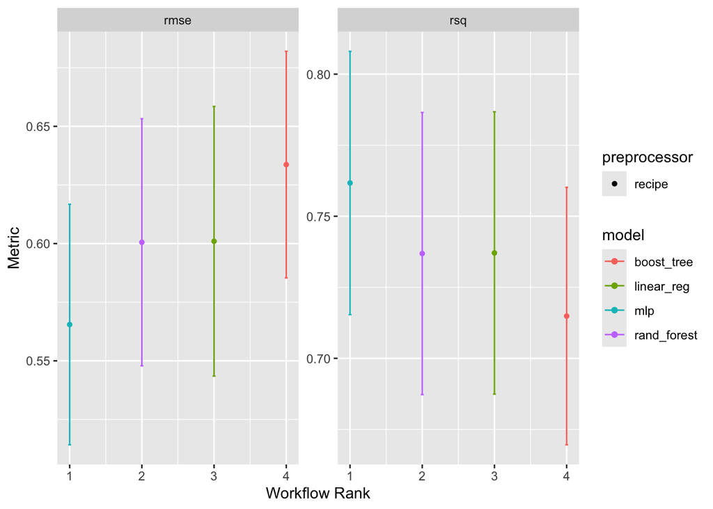

```r
install.packages("xgboost")
library(xgboost)
xg_model <- boost_tree() %>%
  set_engine("xgboost") %>%
  set_mode("regression")

xg_wf <- workflow() %>%
  add_recipe(rec) %>%
  add_model(xg_model) %>%
  fit(data = camels_train)

nn_model <- mlp() %>%
  set_engine("nnet") %>%
  set_mode("regression")

nn_wf <- workflow() %>%
  add_recipe(rec) %>%
  add_model(nn_model) %>%
  fit(data = camels_train)

wf <- workflow_set(list(rec), list(lm_model, rf_model, xg_model, nn_model)) %>%
  workflow_map('fit_resamples', resamples = camels_cv)

autoplot(wf)
```

```r
rank_results(wf, rank_metric = "rsq", select_best = TRUE)
```

```
# A tibble: 8 × 9
  wflow_id          .config .metric  mean std_err     n preprocessor model  rank
  <chr>             <chr>   <chr>   <dbl>   <dbl> <int> <chr>        <chr> <int>
1 recipe_mlp        Prepro… rmse    0.565  0.0312    10 recipe       mlp       1
2 recipe_mlp        Prepro… rsq     0.762  0.0282    10 recipe       mlp       1
3 recipe_linear_reg Prepro… rmse    0.601  0.0350    10 recipe       line…     2
4 recipe_linear_reg Prepro… rsq     0.737  0.0302    10 recipe       line…     2
5 recipe_rand_fore… Prepro… rmse    0.601  0.0320    10 recipe       rand…     3
6 recipe_rand_fore… Prepro… rsq     0.737  0.0302    10 recipe       rand…     3
7 recipe_boost_tree Prepro… rmse    0.634  0.0294    10 recipe       boos…     4
8 recipe_boost_tree Prepro… rsq     0.715  0.0275    10 recipe       boos…     4
```

After evaluating the models and comparing them, I would choose to move forward with the neural network model. It’s rsq was the highest of the four and it had the lowest rmse, indicating that it is the most effective model.

# Question 4

```r
set.seed(64)

cm <- camels |>
  mutate(logQmean = log(q_mean)) |>
  select(logQmean, p_mean, aridity, soil_depth_pelletier, max_water_content, organic_frac, frac_snow, pet_mean, soil_depth_statsgo, elev_mean) |>
  drop_na()

cm_split <- initial_split(cm, prop = 0.75)
cm_train <- training(cm_split)
cm_test  <- testing(cm_split)

cm_cv <- vfold_cv(cm_train, v = 10)
```

```r
rec2 <-  recipe(logQmean ~ ., data = cm_train) %>%
  step_scale(p_mean, aridity, soil_depth_pelletier, max_water_content, organic_frac, frac_snow, pet_mean, soil_depth_statsgo, elev_mean) %>%
  step_center(p_mean, aridity, soil_depth_pelletier, max_water_content, organic_frac, frac_snow, pet_mean, soil_depth_statsgo, elev_mean)

bkd_data <- prep(rec2, cm_train) |>
  bake(new_data = NULL)
```

I chose this recipe because it aggregates the predictor variables under the logQmean, and ensures that they are all comparable. Using step_scale and step_center makes it so all of the predictor variables are more readily analyzable across a similar plane, reducing variability in the results.

```r
rf_md <- rand_forest() %>%
  set_engine("ranger", importance = "impurity") %>%
  set_mode("regression")

xg_md <- boost_tree() %>%
  set_engine("xgboost") %>%
  set_mode("regression")

nn_md <- mlp() %>%
  set_engine("nnet") %>%
  set_mode("regression")
```

```r
wkfl <- workflow_set(list(rec2), list(rf_md,
                                   xg_md,
                                   nn_md)) |>
  workflow_map("fit_resamples", resamples = cm_cv)
```

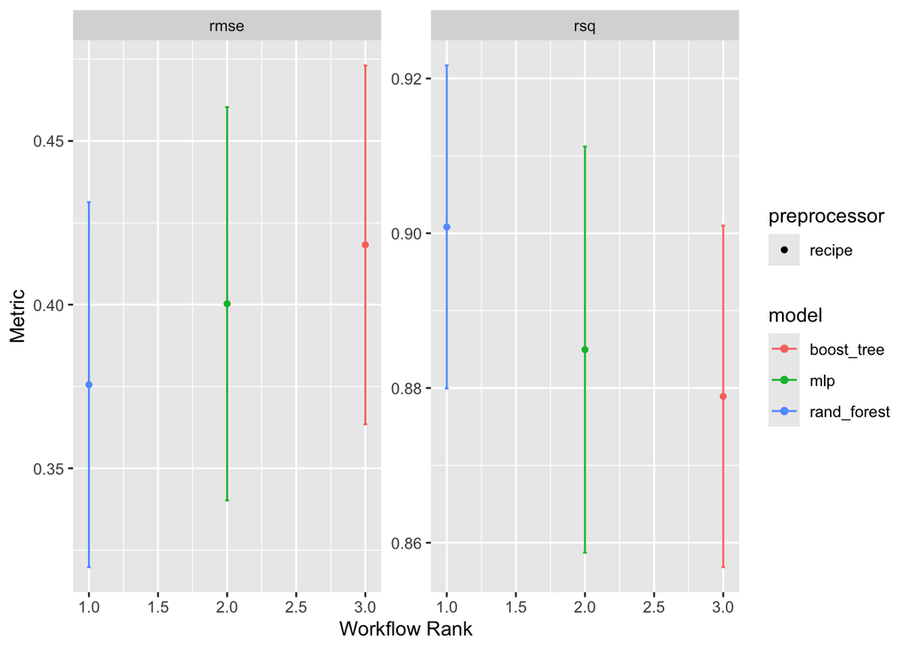

```r
autoplot(wkfl)
```

```r
rank_results(wkfl, rank_metric = "rsq", select_best = TRUE)
```

```
# A tibble: 6 × 9
  wflow_id          .config .metric  mean std_err     n preprocessor model  rank
  <chr>             <chr>   <chr>   <dbl>   <dbl> <int> <chr>        <chr> <int>
1 recipe_rand_fore… Prepro… rmse    0.376  0.0339    10 recipe       rand…     1
2 recipe_rand_fore… Prepro… rsq     0.901  0.0127    10 recipe       rand…     1
3 recipe_mlp        Prepro… rmse    0.400  0.0365    10 recipe       mlp       2
4 recipe_mlp        Prepro… rsq     0.885  0.0159    10 recipe       mlp       2
5 recipe_boost_tree Prepro… rmse    0.418  0.0333    10 recipe       boos…     3
6 recipe_boost_tree Prepro… rsq     0.879  0.0134    10 recipe       boos…     3
```

I think the random forest model would be the best for evaluating the data, since it had an rsq of 0.9 and had the lowest r mean standard error out of the three models I tested. When ranked by rsq, the random forest model was ranked number 1, indicating that the metrics for ranking the models favored the random forest model.

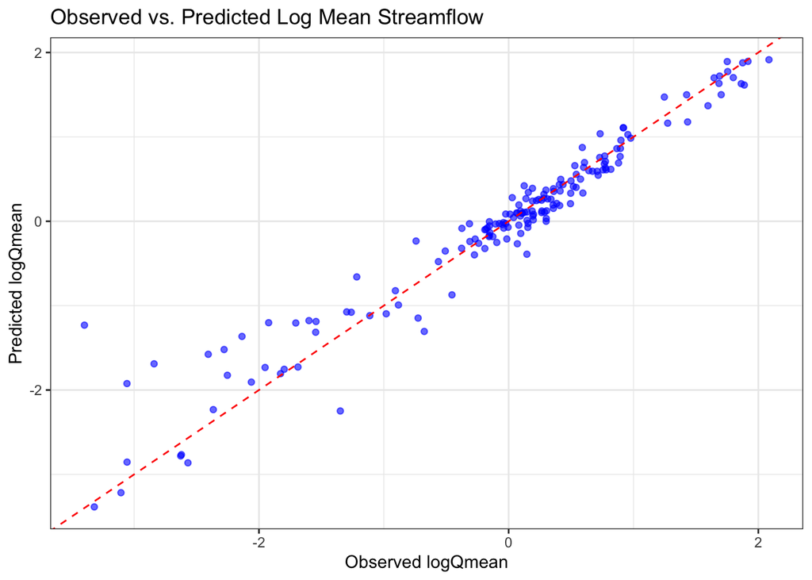

```r
set.seed(64)

rf_wf <- workflow() %>%
  add_recipe(rec2) %>%
  add_model(rf_md)

rf_fit <- rf_wf %>%
  fit(data = cm_train)

rf_predictions <- augment(rf_fit, new_data = cm_test)

ggplot(rf_predictions, aes(x = logQmean, y = .pred)) +
  geom_point(color = "blue", alpha = 0.6) +
  geom_abline(slope = 1, intercept = 0, color = "red", linetype = "dashed") +
  labs(
    title = "Observed vs. Predicted Log Mean Streamflow",
    x = "Observed logQmean",
    y = "Predicted logQmean"
  ) +
  theme_bw()
```

After testing my model with the data, accounting for the various predictor variables, I found that the observed values align with the predicted values fairly closely. Most of the values are skewed to the right side of the graph and centered around the 0,0 point, indicating that the model might not have captured a large amount of variability, which could be a result of being skewed towards smaller values or not having enough predictor variables to account for this. Otherwise, the model seems to be an accurate representation of the logQmean data and reflects the relationship between the predicted and observed values.